# sklearn.linear_model.LinearRegression

**class*sklearn.linear_model.LinearRegression(*, *fit_intercept=True*, *normalize='deprecated'*, *copy_X=True*, *n_jobs=None*, *positive=False*)[[source]](https://github.com/scikit-learn/scikit-learn/blob/f3f51f9b6/sklearn/linear_model/_base.py#L529)**

Ordinary least squares Linear Regression.

LinearRegression fits a linear model with coefficients w = (w1, …, wp) to minimize the residual sum of squares between the observed targets in the dataset, and the targets predicted by the linear approximation.

**Parameters:**

**fit_intercept**bool, default=True**

Whether to calculate the intercept for this model. If set to False, no intercept will be used in calculations (i.e. data is expected to be centered).

Deprecated since version 1.0: `normalize` was deprecated in version 1.0 and will be removed in 1.2.

**copy_X**bool, default=True**

If True, X will be copied; else, it may be overwritten.

**n_jobs**int, default=None**

The number of jobs to use for the computation. This will only provide speedup in case of sufficiently large problems, that is if firstly `n_targets > 1` and secondly `X` is sparse or if `positive` is set to `True`. `None` means 1 unless in a [`joblib.parallel_backend`](https://joblib.readthedocs.io/en/latest/parallel.html#joblib.parallel_backend) context. `-1` means using all processors. See [Glossary](https://scikit-learn.org/1.1/glossary.html#term-n_jobs) for more details.

**positive**bool, default=False**

When set to `True`, forces the coefficients to be positive. This option is only supported for dense arrays.

New in version 0.24.

**Attributes:**

**coef_**array of shape (n_features, ) or (n_targets, n_features)**

Estimated coefficients for the linear regression problem. If multiple targets are passed during the fit (y 2D), this is a 2D array of shape (n_targets, n_features), while if only one target is passed, this is a 1D array of length n_features.

**rank_**int**

Rank of matrix `X`. Only available when `X` is dense.

**singular_**array of shape (min(X, y),)**

Singular values of `X`. Only available when `X` is dense.

**intercept_**float or array of shape (n_targets,)**

Independent term in the linear model. Set to 0.0 if `fit_intercept = False`.

**n_features_in_**int**

Number of features seen during fit.

New in version 0.24.

**feature_names_in_**ndarray of shape (`n_features_in_`,)**

Names of features seen during fit. Defined only when `X` has feature names that are all strings.

New in version 1.0.

See also

**`Ridge`**

Ridge regression addresses some of the problems of Ordinary Least Squares by imposing a penalty on the size of the coefficients with l2 regularization.

**`Lasso`**

The Lasso is a linear model that estimates sparse coefficients with l1 regularization.

**`ElasticNet`**

Elastic-Net is a linear regression model trained with both l1 and l2 -norm regularization of the coefficients.

#### Notes

From the implementation point of view, this is just plain Ordinary Least Squares (scipy.linalg.lstsq) or Non Negative Least Squares (scipy.optimize.nnls) wrapped as a predictor object.

#### Examples

```
>>> import numpy as np
>>> from sklearn.linear_model import LinearRegression
>>> X = np.array([[1, 1], [1, 2], [2, 2], [2, 3]])
>>> # y = 1 * x_0 + 2 * x_1 + 3
>>> y = np.dot(X, np.array([1, 2])) + 3
>>> reg = LinearRegression().fit(X, y)
>>> reg.score(X, y)
1.0
>>> reg.coef_
array([1., 2.])
>>> reg.intercept_
3.0...
>>> reg.predict(np.array([[3, 5]]))
array([16.])
```

#### Methods

| `fit`(X, y[, sample_weight]) | Fit linear model. |
| --- | --- |
| `get_params`([deep]) | Get parameters for this estimator. |
| `predict`(X) | Predict using the linear model. |
| `score`(X, y[, sample_weight]) | Return the coefficient of determination of the prediction. |
| `set_params`(**params) | Set the parameters of this estimator. |

**fit(*X*, *y*, *sample_weight=None*)[[source]](https://github.com/scikit-learn/scikit-learn/blob/f3f51f9b6/sklearn/linear_model/_base.py#L652)**

Fit linear model.

**Parameters:**

**X**{array-like, sparse matrix} of shape (n_samples, n_features)**

Training data.

**y**array-like of shape (n_samples,) or (n_samples, n_targets)**

Target values. Will be cast to X’s dtype if necessary.

**sample_weight**array-like of shape (n_samples,), default=None**

Individual weights for each sample.

New in version 0.17: parameter *sample_weight* support to LinearRegression.

**Returns:**

**self**object**

Fitted Estimator.

**get_params(*deep=True*)[[source]](https://github.com/scikit-learn/scikit-learn/blob/f3f51f9b6/sklearn/base.py#L194)**

Get parameters for this estimator.

**Parameters:**

**deep**bool, default=True**

If True, will return the parameters for this estimator and contained subobjects that are estimators.

**Returns:**

**params**dict**

Parameter names mapped to their values.

**predict(*X*)[[source]](https://github.com/scikit-learn/scikit-learn/blob/f3f51f9b6/sklearn/linear_model/_base.py#L372)**

Predict using the linear model.

**Parameters:**

**X**array-like or sparse matrix, shape (n_samples, n_features)**

Samples.

**Returns:**

**C**array, shape (n_samples,)**

Returns predicted values.

**score(*X*, *y*, *sample_weight=None*)[[source]](https://github.com/scikit-learn/scikit-learn/blob/f3f51f9b6/sklearn/base.py#L677)**

Return the coefficient of determination of the prediction.

The coefficient of determination $R^2$ is defined as $(1 - \frac{u}{v})$, where $u$ is the residual sum of squares `((y_true - y_pred)** 2).sum()` and $v$ is the total sum of squares `((y_true - y_true.mean()) ** 2).sum()`. The best possible score is 1.0 and it can be negative (because the model can be arbitrarily worse). A constant model that always predicts the expected value of `y`, disregarding the input features, would get a $R^2$ score of 0.0.

**Parameters:**

**X**array-like of shape (n_samples, n_features)**

Test samples. For some estimators this may be a precomputed kernel matrix or a list of generic objects instead with shape `(n_samples, n_samples_fitted)`, where `n_samples_fitted` is the number of samples used in the fitting for the estimator.

**y**array-like of shape (n_samples,) or (n_samples, n_outputs)**

True values for `X`.

**sample_weight**array-like of shape (n_samples,), default=None**

Sample weights.

**Returns:**

**score**float**

$R^2$ of `self.predict(X)` wrt. `y`.

#### Notes

The $R^2$ score used when calling `score` on a regressor uses `multioutput='uniform_average'` from version 0.23 to keep consistent with default value of `r2_score`. This influences the `score` method of all the multioutput regressors (except for `MultiOutputRegressor`).

**set_params(**params)[[source]](https://github.com/scikit-learn/scikit-learn/blob/f3f51f9b6/sklearn/base.py#L218)**

Set the parameters of this estimator.

The method works on simple estimators as well as on nested objects (such as `Pipeline`). The latter have parameters of the form `<component>__<parameter>` so that it’s possible to update each component of a nested object.

**Parameters:**

**paramsdict**

Estimator parameters.

**Returns:**

**self**estimator instance**

Estimator instance.

## Examples using `sklearn.linear_model.LinearRegression`

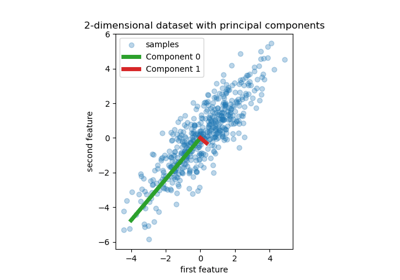

Principal Component Regression vs Partial Least Squares Regression

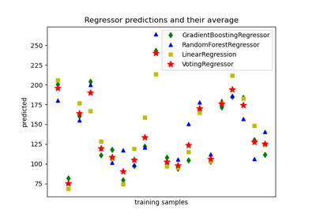

Plot individual and voting regression predictions

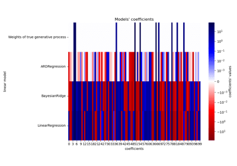

Comparing Linear Bayesian Regressors

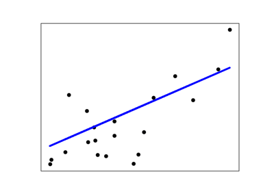

Linear Regression Example

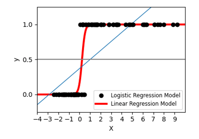

Logistic function

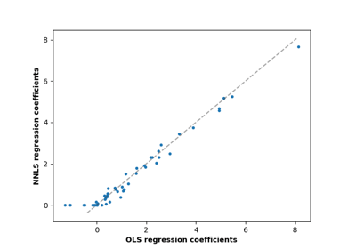

Non-negative least squares

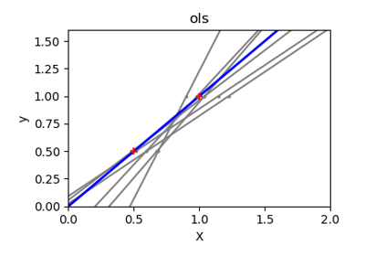

Ordinary Least Squares and Ridge Regression Variance

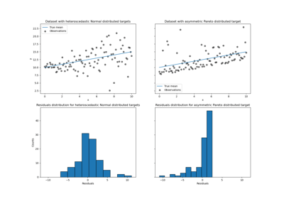

Quantile regression

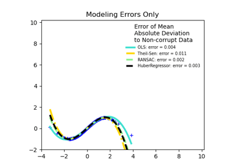

Robust linear estimator fitting

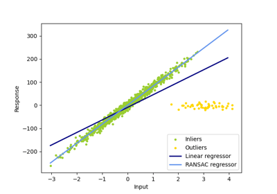

Robust linear model estimation using RANSAC

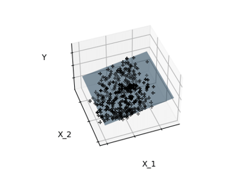

Sparsity Example: Fitting only features 1 and 2

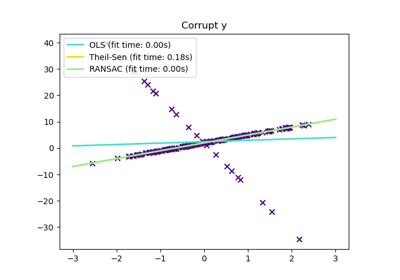

Theil-Sen Regression

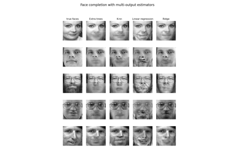

Face completion with a multi-output estimators

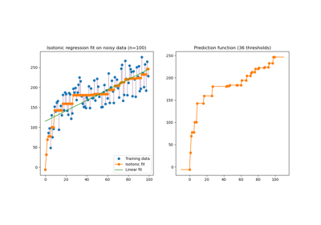

Isotonic Regression

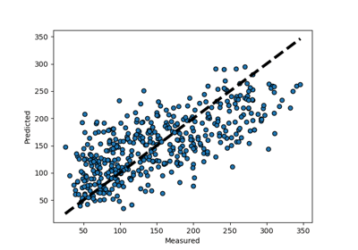

Plotting Cross-Validated Predictions

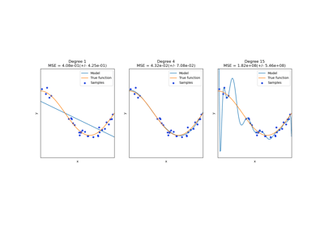

Underfitting vs. Overfitting

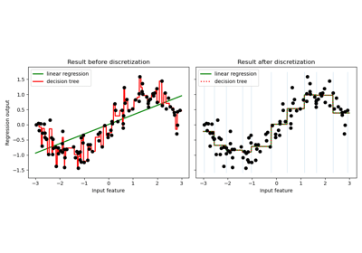

Using KBinsDiscretizer to discretize continuous features

© 2007–2022 The scikit-learn developers  
Licensed under the 3-clause BSD License.  
https://scikit-learn.org/1.1/modules/generated/sklearn.linear_model.LinearRegression.html